# Empirical Bayes deconvolution

Joon-Ho Lee (joonho@berkeley.edu)

February 7, 2020

# 1 Introduction

- This document explores Empirical Bayes methods for learning prior distributions from data.
- An unknown prior distribution ($g$) has yielded (unobservable) parameters, each of which produces a data point from a parametric exponential family ($f$).
- The goal is to estimate the unknown prior ($g$-modeling) by deconvolution and Empirical Bayes methods.

# 2 Bayes deconvolution problem

- Unknown prior density $g(\theta)$ gives unobserved realizations:

$$\Theta_1, \Theta_2, ..., \Theta_N \overset{\text{iid}}{\sim} g(\theta)$$

- Each $\Theta_k$ gives observed $X_k \sim p_{\Theta_{k}}(x)$ where $p_{\Theta_{k}}$ is known.
- The marginal density of $X$ is

$$f(x) = \int{p_{\theta}(x)g(\theta)d\theta}.$$

- We wish to estimate $g(\theta)$ from $X_1, X_2, ..., X_N$.
- In the normal model of $p_{\Theta_{k}}$, $f(x)$ is the *convolution* of $g(\theta)$ with a standard normal density.
- The empirical Bayes task is one of *deconvolution*: using the observed sample $X$ from $f(x)$ to estimate $g(\theta)$. Efron (2016) refers to this as the **$g$-modeling**.

# 3 A simulation example

We start with a simulated Poisson example where the $\Theta_i$ are drawn from a chi-squared density with 10 degrees of freedom and the $X_i|\Theta_i$ are Poisson with expectation $\Theta_i:$

$$\Theta_i \sim \chi^2_{10} \mbox{ and } X_i|\Theta_i \sim \mbox{Poisson}(\Theta_i)$$

The $\Theta_i$ for this setting, with `N = 1000` observations can be generated as follows.

```r
set.seed(238923) ## for reproducibility
N <- 1000
Theta <- rchisq(N,  df = 10)
```

Next, the $X_i|\Theta_i$, for each of `nSIM = 1000` simulations can be generated as below.

```r
nSIM <- 1000
data <- sapply(seq_len(nSIM), function(x) rpois(n = N, lambda = Theta))
```

We take the discrete set $\mathcal{T}=(1, 2, \ldots, 32)$ as the $\Theta$-space and apply the `deconv` function in the package `deconvolveR` to estimate $g(\theta).$

```r
library(deconvolveR)
tau <- seq(1, 32)
results <- apply(data, 2,
                 function(x) deconv(tau = tau, X = x, ignoreZero = FALSE,
                                    c0 = 1))
```

Some warnings are emitted by the `nlm` routine used for optimization, but they are mostly inconsequential.

Since `deconv` works on a sample at a time, the result above is a list of lists from which various statistics can be extracted. Below, we construct a table of values for various values of $\Theta$.

```r
g <- sapply(results, function(x) x$stats[, "g"])
mean <- apply(g, 1, mean)
SE.g <- sapply(results, function(x) x$stats[, "SE.g"])
sd <- apply(SE.g, 1, mean)
Bias.g <- sapply(results, function(x) x$stats[, "Bias.g"])
bias <- apply(Bias.g, 1, mean)
gTheta <- pchisq(tau, df = 10) - pchisq(c(0, tau[-length(tau)]), df = 10)
gTheta <- gTheta / sum(gTheta)
simData <- data.frame(theta = tau, gTheta = gTheta,
                      Mean = mean, StdDev = sd, Bias = bias,
                      CoefVar = sd / mean)
table1 <- transform(simData,
                    gTheta = 100 * gTheta,
                    Mean = 100 * Mean,
                    StdDev = 100 * StdDev,
                    Bias = 100 * Bias)
```

The table below summarizes the results for some chosen values of $\theta .$

```r
knitr::kable(table1, row.names=FALSE)
```

| theta | gTheta | Mean | StdDev | Bias | CoefVar |
| --- | --- | --- | --- | --- | --- |
| 1 | 0.0172185 | 0.6820001 | 0.1937458 | 0.0685944 | 0.2840847 |
| 2 | 0.3489128 | 1.2061456 | 0.2525607 | 0.0796625 | 0.2093948 |
| 3 | 1.4922065 | 2.0949763 | 0.2964558 | 0.0671656 | 0.1415079 |
| 4 | 3.4090732 | 3.4900169 | 0.3118752 | 0.0049860 | 0.0893621 |
| 5 | 5.6191465 | 5.4416722 | 0.3635378 | -0.1235865 | 0.0668063 |
| 6 | 7.5945186 | 7.7466500 | 0.5529804 | -0.2869750 | 0.0713832 |
| 7 | 8.9854272 | 9.8229178 | 0.7422870 | -0.3762866 | 0.0755669 |
| 8 | 9.6646719 | 10.8792442 | 0.7000810 | -0.2657252 | 0.0643502 |
| 9 | 9.6772110 | 10.6693863 | 0.5000306 | -0.0009846 | 0.0468659 |
| 10 | 9.1646990 | 9.5316279 | 0.4917673 | 0.2588187 | 0.0515932 |
| 11 | 8.3008522 | 7.9739547 | 0.6301661 | 0.4001765 | 0.0790281 |
| 12 | 7.2490530 | 6.4148720 | 0.6705992 | 0.4001051 | 0.1045382 |
| 13 | 6.1409274 | 5.0928873 | 0.5842746 | 0.2916455 | 0.1147236 |
| 14 | 5.0700511 | 4.0912117 | 0.4291524 | 0.1170772 | 0.1048962 |
| 15 | 4.0946148 | 3.3421426 | 0.3119862 | -0.0683187 | 0.0933492 |
| 16 | 3.2442447 | 2.7450822 | 0.3066087 | -0.2154847 | 0.1116938 |
| 17 | 2.5278543 | 2.2367993 | 0.3471047 | -0.2961904 | 0.1551792 |
| 18 | 1.9408110 | 1.7801191 | 0.3533730 | -0.2983298 | 0.1985109 |
| 19 | 1.4706848 | 1.3599634 | 0.3060631 | -0.2300910 | 0.2250524 |
| 20 | 1.1014405 | 0.9810001 | 0.2246999 | -0.1225092 | 0.2290519 |
| 21 | 0.8162391 | 0.6707126 | 0.1532270 | -0.0257726 | 0.2284541 |
| 22 | 0.5991364 | 0.4472820 | 0.1138911 | 0.0315471 | 0.2546294 |
| 23 | 0.4359768 | 0.2994326 | 0.0938056 | 0.0556471 | 0.3132777 |
| 24 | 0.3147448 | 0.2063884 | 0.0797190 | 0.0614700 | 0.3862571 |
| 25 | 0.2255788 | 0.1496337 | 0.0677919 | 0.0602422 | 0.4530522 |
| 26 | 0.1605963 | 0.1162420 | 0.0579981 | 0.0579799 | 0.4989432 |
| 27 | 0.1136301 | 0.0975924 | 0.0508985 | 0.0570398 | 0.5215412 |
| 28 | 0.0799412 | 0.0876434 | 0.0470081 | 0.0575009 | 0.5363559 |
| 29 | 0.0559428 | 0.0832912 | 0.0468951 | 0.0588444 | 0.5630262 |
| 30 | 0.0389560 | 0.0829338 | 0.0512410 | 0.0603671 | 0.6178538 |
| 31 | 0.0270024 | 0.0856187 | 0.0605544 | 0.0611789 | 0.7072568 |
| 32 | 0.0186362 | 0.0905593 | 0.0748773 | 0.0602053 | 0.8268317 |

Although, the coefficient of variation of $\hat{g}(\theta)$ is still large, the $g(\theta)$ estimates are reasonable.

We can compare the empirical standard deviations and biases of $g(\hat{\alpha})$ with the approximation given by the formulas in the paper.

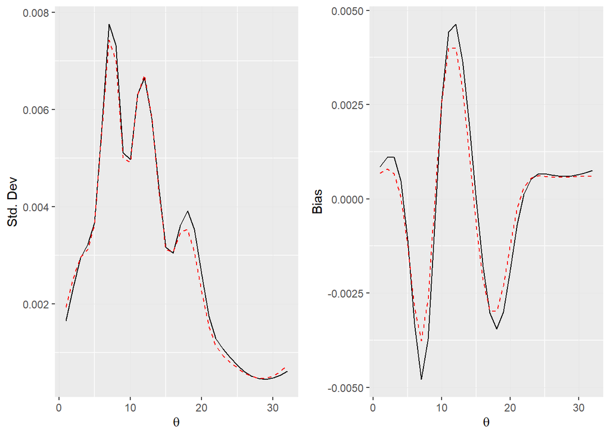

```r
library(ggplot2)
library(cowplot)
theme_set(theme_get() +
          theme(panel.grid.major = element_line(colour = "gray90",
                                                size = 0.2),
                panel.grid.minor = element_line(colour = "gray98",
                                                size = 0.5)))
p1 <- ggplot(data = as.data.frame(results[[1]]$stats)) +
    geom_line(mapping = aes(x = theta, y = SE.g), color = "black", linetype = "solid") +
    geom_line(mapping = aes(x = simData$theta, y = simData$StdDev), color = "red", linetype = "dashed") +
    labs(x = expression(theta), y = "Std. Dev")

p2 <- ggplot(data = as.data.frame(results[[1]]$stats)) +
    geom_line(mapping = aes(x = theta, y = Bias.g), color = "black", linetype = "solid") +
    geom_line(mapping = aes(x = simData$theta, y = simData$Bias), color = "red", linetype = "dashed") +
    labs(x = expression(theta), y = "Bias")
plot_grid(plotlist = list(p1, p2), ncol = 2)
```

The approximation is quite good for the standard deviations, but a little too small for the biases.

# References

Efron, Bradley. 2016. “Empirical Bayes Deconvolution Estimates.” *Biometrika* 103 (1): 1–20.